# Clustering

- Show All Code
- Hide All Code
- View Source

```python
import warnings
warnings.filterwarnings("ignore")
import pandas as pd
import numpy as np
from sklearn.preprocessing import StandardScaler
from sklearn.cluster import KMeans, DBSCAN, AgglomerativeClustering
from sklearn.metrics import silhouette_score
from scipy.spatial.distance import cdist
import seaborn as sns
import matplotlib.pyplot as plt
from sklearn.metrics import confusion_matrix
from scipy.optimize import linear_sum_assignment
from sklearn.metrics import precision_score, recall_score, f1_score, accuracy_score
from scipy.cluster.hierarchy import dendrogram, linkage
```

## Introduction

In the field of chronic diseases research, understanding complex diseases like diabetes often involves discerning hidden patterns in data. This project utilizes clustering techniques, specifically K-Means, DBSCAN, and Hierarchical clustering, to analyze Diabetes from the Framingham Heart Study R Project (n.d.). The use of these diverse methods allows for a comprehensive exploration of diabetes prediction and understanding. Each method, with its unique approach, helps in identifying distinct groups and complex relationships among various factors. By focusing on diabetes as the core subject, this analysis aims to decode how different risk factors, demographics, and lifestyle choices intersect, contributing to the disease’s development and progression.

## Theory

### K Means Clustering

- K-means clustering divides data into k distinct groups. Initially, it randomly selects centroids from the data, which are like central points for each group. Data points are then grouped with the nearest centroid, forming initial clusters. After this, the average position of all the points in each cluster is calculated, creating new centroids. This process of assigning data points to the nearest centroid and recalculating the centroids is repeated until the clusters stabilize, usually meaning they don’t change much between iterations.

For evaluating how well the clustering worked, two common methods are the Elbow Method and Silhouette Analysis. The Elbow Method helps to choose a suitable number of clusters (k). It involves plotting the Sum of Squared Distances also known as inertia between data points and their respective cluster centroids against a range of k values. The elbow point, where the rate of decrease sharply changes, suggests a good number of clusters. On the other hand, Silhouette Analysis measures how similar a data point is to its own cluster compared to other clusters. It helps understand how well-separated the clusters are, with higher silhouette scores indicating better-defined clusters. Dabbura (2023)

### DBSAN

- DBSCAN looks at clustering from a density point of view. It groups points that are closely packed together, marking points that are too far from any cluster as outliers. The process starts by picking a point and finding all points within a certain distance, then a cluster is formed if there are enough pints. DBSCAN then checks the points around these new points, expanding the cluster if necessary. This method is particularly useful for data with irregular shapes. The key parameters are the maximum distance (also know as eps which is the radius of the neighborhood around each data point.) between points to be considered neighbors and the minimum number of points to form a dense region. Unlike K-Means, specifying the number of clusters is not required.
- For evaluating DBSCAN, using the Silhouette score is more appropriate than the Elbow method. The Elbow method is typically used for K Means Clustering where you need to determine the optimal number of clusters. In contrast, DBSCAN does not require specifying the number of clusters. The Silhouette score, which measures the quality of clusters by how well-separated they are, is suitable for evaluating the model performance of DBSCAN.

### Hierarchical clustering

- Hierarchical clustering builds a tree of clusters by progressively linking together data points or existing clusters. Initially, each point is a cluster. The closest pairs of points (or clusters) are then merged into new clusters. This process is repeated, gradually forming larger clusters. The result can be visualized as a tree or dendrogram, showing the hierarchy of clustering, it is simlilar to the structure of a decision tree. An advantage of hierarchical clustering is that we don’t need to decide the number of clusters in advance. We can choose the number of clusters by chopping the dendrogram at the desired level.
- For hierarchical clustering, the Silhouette score is a better method. While the Elbow method is useful for algorithms like K-means where you need to predetermine the number of clusters, hierarchical clustering provides a tree-like structure of data. The Silhouette score can help in determining the quality of the clusters formed at different levels. This method offers a clear insight into the distinctiveness of the clusters formed.

## Methods

### Data preparation

```python
# Load the Frammingham Heart Study data set
data = pd.read_csv("data/frmgham2.csv")
data.head()
```

|  | RANDID | SEX | TOTCHOL | AGE | SYSBP | DIABP | CURSMOKE | CIGPDAY | BMI | DIABETES | ... | CVD | HYPERTEN | TIMEAP | TIMEMI | TIMEMIFC | TIMECHD | TIMESTRK | TIMECVD | TIMEDTH | TIMEHYP |
| --- | --- | --- | --- | --- | --- | --- | --- | --- | --- | --- | --- | --- | --- | --- | --- | --- | --- | --- | --- | --- | --- |
| 0 | 2448 | 1 | 195.0 | 39 | 106.0 | 70.0 | 0 | 0.0 | 26.97 | 0 | ... | 1 | 0 | 8766 | 6438 | 6438 | 6438 | 8766 | 6438 | 8766 | 8766 |
| 1 | 2448 | 1 | 209.0 | 52 | 121.0 | 66.0 | 0 | 0.0 | NaN | 0 | ... | 1 | 0 | 8766 | 6438 | 6438 | 6438 | 8766 | 6438 | 8766 | 8766 |
| 2 | 6238 | 2 | 250.0 | 46 | 121.0 | 81.0 | 0 | 0.0 | 28.73 | 0 | ... | 0 | 0 | 8766 | 8766 | 8766 | 8766 | 8766 | 8766 | 8766 | 8766 |
| 3 | 6238 | 2 | 260.0 | 52 | 105.0 | 69.5 | 0 | 0.0 | 29.43 | 0 | ... | 0 | 0 | 8766 | 8766 | 8766 | 8766 | 8766 | 8766 | 8766 | 8766 |
| 4 | 6238 | 2 | 237.0 | 58 | 108.0 | 66.0 | 0 | 0.0 | 28.50 | 0 | ... | 0 | 0 | 8766 | 8766 | 8766 | 8766 | 8766 | 8766 | 8766 | 8766 |

5 rows × 39 columns

### Missing data handelling and normalization

```python
# Check for missing data and calculate percentages
missing_data = data.isnull().mean()

# Drop columns with more than 50% missing data
threshold = 0.5
columns_to_drop = missing_data[missing_data > threshold].index
data.drop(columns=columns_to_drop, inplace=True)
data = data.iloc[:, 1:]

# Remove rows with missing data as their percentages are low
data.dropna(inplace=True)

# Set target variables
target = data.pop('DIABETES')

# Scale the data
scaler = StandardScaler()
data_scaled = scaler.fit_transform(data)
```

### K-Means Clustering

**Hyperparameter tuning function**

```python
import sklearn.cluster

# THIS WILL ITERATE OVER ONE HYPER-PARAMETER (GRID SEARCH)
# AND RETURN THE CLUSTER RESULT THAT OPTIMIZES THE SILHOUETTE SCORE
def maximize_silhouette(X,algo="birch",nmax=20,i_plot=False):

    # PARAM
    i_print=False

    #FORCE CONTIGUOUS
    X=np.ascontiguousarray(X)

    # LOOP OVER HYPER-PARAM
    params=[]; sil_scores=[]
    sil_max=-10
    for param in range(2,nmax+1):
        if(algo=="birch"):
            model = sklearn.cluster.Birch(n_clusters=param).fit(X)
            labels=model.predict(X)

        if(algo=="ag"):
            model = sklearn.cluster.AgglomerativeClustering(n_clusters=param).fit(X)
            labels=model.labels_

        if(algo=="dbscan"):
            param=0.25*(param-1)
            model = sklearn.cluster.DBSCAN(eps=param).fit(X)
            labels=model.labels_

        if(algo=="kmeans"):
            model = sklearn.cluster.KMeans(n_clusters=param).fit(X)
            labels=model.predict(X)

        try:
            sil_scores.append(sklearn.metrics.silhouette_score(X,labels))
            params.append(param)
        except:
            continue

        if(i_print): print(param,sil_scores[-1])

        if(sil_scores[-1]>sil_max):
             opt_param=param
             sil_max=sil_scores[-1]
             opt_labels=labels

    print("OPTIMAL PARAMETER =",opt_param)

    if(i_plot):
        fig, ax = plt.subplots()
        ax.plot(params, sil_scores, "-o")
        ax.set(xlabel='Hyper-parameter', ylabel='Silhouette')
        plt.show()

    return opt_labels
```

**Utility Plot function**

```python
# UTILITY PLOTTING FUNCTION
def plot(X,color_vector):
    fig, ax = plt.subplots()
    ax.scatter(X[:,0], X[:,1],c=color_vector, alpha=0.5) #, c=y
    ax.set(xlabel='Feature-1 (x_1)', ylabel='Feature-2 (x_2)',
    title='Cluster data')
    ax.grid()
    # fig.savefig("test.png")
    plt.show()
```

**Elbow Method**

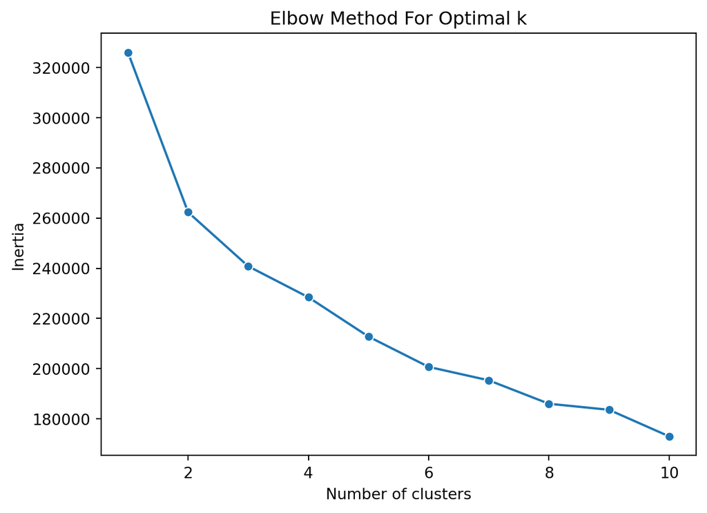

```python
# Elbow method for K Means
inertia = []
K = range(1, 11)
for k in K:
    kmeanModel = KMeans(n_clusters=k)
    kmeanModel.fit(data_scaled)
    inertia.append(kmeanModel.inertia_)

# Plotting the elbow method
sns.lineplot(x=K, y=inertia, marker="o")
plt.title('Elbow Method For Optimal k')
plt.xlabel('Number of clusters')
plt.ylabel('Inertia')
plt.show()
```

**Silhouette Method**

```
OPTIMAL PARAMETER = 2
```

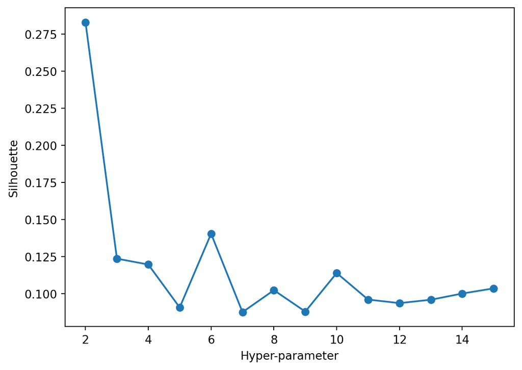

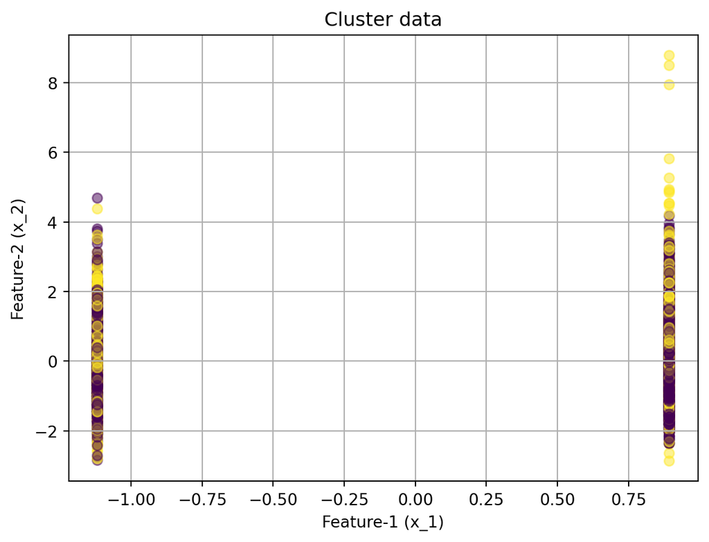

```python
opt_labels=maximize_silhouette(data_scaled,algo="kmeans",nmax=15, i_plot=True)
plot(data_scaled,opt_labels)
```

**Final Results for optimal K of K-Means**

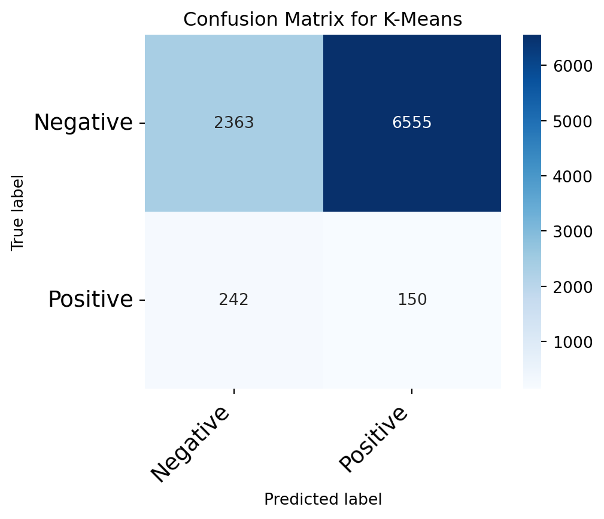

```
[[2363 6555]
 [ 242  150]]
Accuracy: 0.2699
Precision: 0.0224
Recall: 0.3827
F1-Score: 0.0423
```

```python
# Confusion Matrix Heatmap, used chatgpt as an assitance, this heat map works well
def plot_confusion_matrix(cm, class_names):
    df_cm = pd.DataFrame(cm, index=class_names, columns=class_names)
    fig = plt.figure(figsize=(5,4))
    try:
        heatmap = sns.heatmap(df_cm, annot=True, fmt="d", cmap='Blues')
    except ValueError:
        raise ValueError("Confusion matrix values must be integers.")

    heatmap.yaxis.set_ticklabels(heatmap.yaxis.get_ticklabels(), rotation=0, ha='right', fontsize=14)
    heatmap.xaxis.set_ticklabels(heatmap.xaxis.get_ticklabels(), rotation=45, ha='right', fontsize=14)
    plt.ylabel('True label')
    plt.xlabel('Predicted label')
    return fig


# Final K-Means Clustering with Optimal k
kmeans_final = KMeans(n_clusters=2)
kmeans_clusters = kmeans_final.fit_predict(data_scaled)
class_names = ['Negative', 'Positive']

# Plot confusion matrix for K-Means
cm_kmeans = confusion_matrix(target, kmeans_clusters)
fig_kmeans = plot_confusion_matrix(cm_kmeans, class_names)
plt.title('Confusion Matrix for K-Means')
plt.show()

print(cm_kmeans)

precision = precision_score(target, kmeans_clusters)
recall = recall_score(target, kmeans_clusters)
f1 = f1_score(target, kmeans_clusters)
accuracy = accuracy_score(target, kmeans_clusters)

print(f"Accuracy: {accuracy:.4f}")
print(f"Precision: {precision:.4f}")
print(f"Recall: {recall:.4f}")
print(f"F1-Score: {f1:.4f}")
```

## DBSCAN

**Silhouette Method**

```
OPTIMAL PARAMETER = 3.5
```

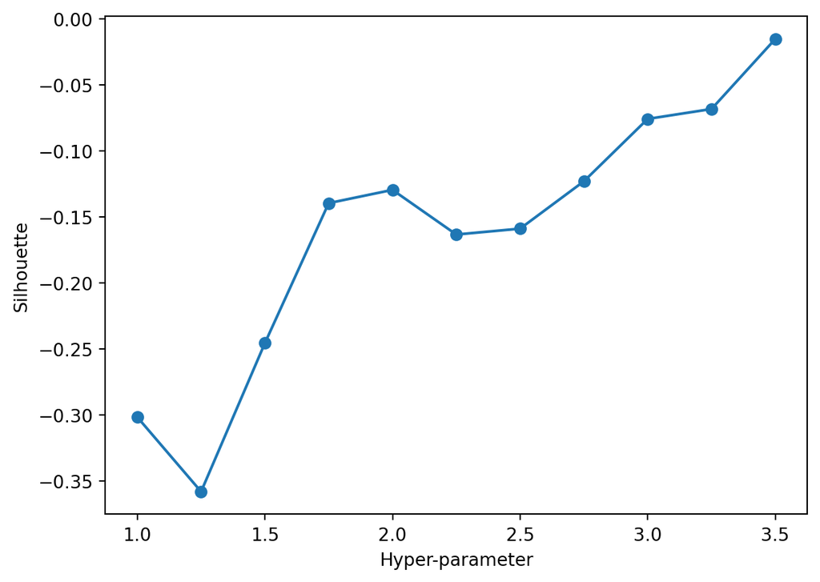

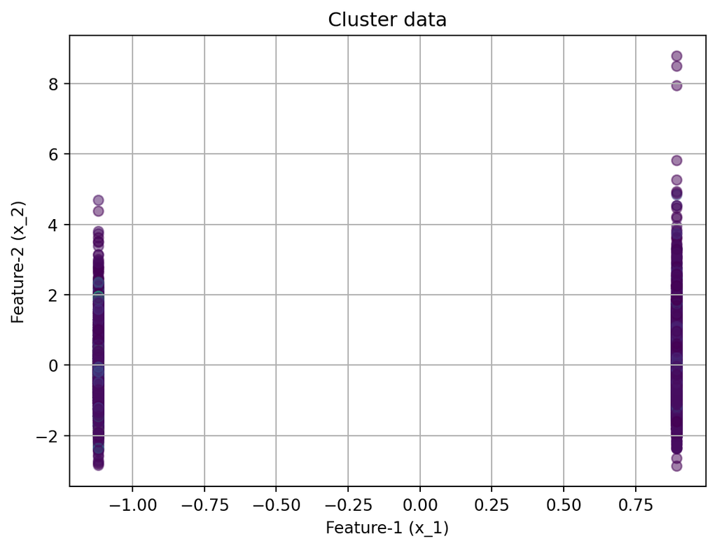

```python
opt_labels=maximize_silhouette(data_scaled,algo="dbscan",nmax=15, i_plot=True)
plot(data_scaled,opt_labels)
```

- The optimal parameter for DBSCAN method is `3.5`, at `eps = 3.5`, the Silhouette score is maximized.

**Final Results for optimal eps of DBSCAN**

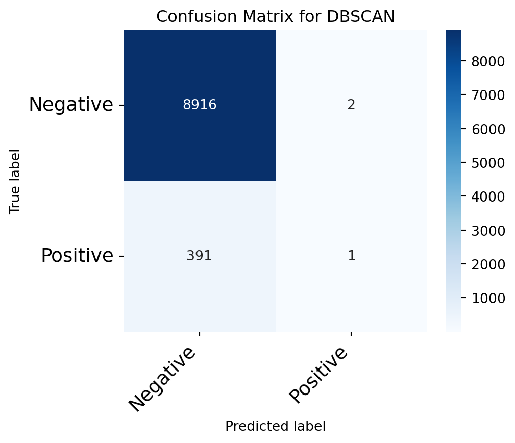

```
Accuracy: 0.9578
Precision: 0.3333
Recall: 0.0026
F1-Score: 0.0051
```

```python
optimal_eps = 3.5
dbscan_final = DBSCAN(eps=optimal_eps)
dbscan_clusters = dbscan_final.fit_predict(data_scaled)

cluster_positive_ratio = []
unique_clusters = set(dbscan_clusters) - {-1}  # Exclude noise if present

# For this section of code, I used chatgpt to help me understand how to convert multi-dimensional data to binary predictions.

for cluster in unique_clusters:
    # Create a mask for the current cluster
    cluster_mask = dbscan_clusters == cluster
    # Calculate the ratio of positive instances in this cluster
    positive_ratio = target[cluster_mask].mean()
    cluster_positive_ratio.append((cluster, positive_ratio))

# Sort clusters by positive ratio and get the cluster with the highest positive ratio
optimal_cluster = sorted(cluster_positive_ratio, key=lambda x: x[1], reverse=True)[0][0]

# Map the DBSCAN clusters to binary predictions
binary_predictions = (dbscan_clusters == optimal_cluster).astype(int)

# Compute metrics
precision = precision_score(target, binary_predictions)
recall = recall_score(target, binary_predictions)
f1 = f1_score(target, binary_predictions)
accuracy = accuracy_score(target, binary_predictions)

# Confusion Matrix
cm = confusion_matrix(target, binary_predictions)
fig_kmeans = plot_confusion_matrix(cm, class_names)
plt.title('Confusion Matrix for DBSCAN')
plt.show()

# Print metrics
print(f"Accuracy: {accuracy:.4f}")
print(f"Precision: {precision:.4f}")
print(f"Recall: {recall:.4f}")
print(f"F1-Score: {f1:.4f}")
```

- **Accuracy (95.78%):** This is high, indicating that a large proportion of predictions match the actual labels. However, in the context of class imbalance, this metric can be misleading.
- **Precision (33.33%):** When the model predicts the positive class, it is correct about one-third of the time. This is relatively low and may be concerning if the positive class is of significant interest.
- **Recall (0.26%)**: This is very low, indicating that the model identifies only a tiny fraction of actual positive cases.
- **F1-Score (0.51%):** This is extremely low, suggesting that the balance between precision and recall is poor. The model is not effective in predicting positive cases.

## Hierarchical clustering

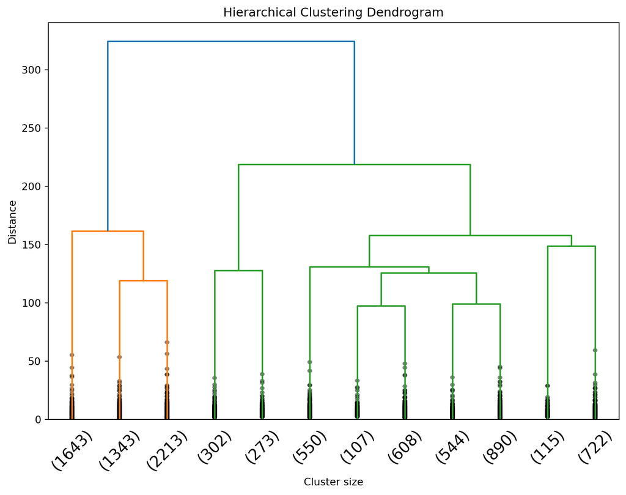

```
OPTIMAL PARAMETER = 2
```

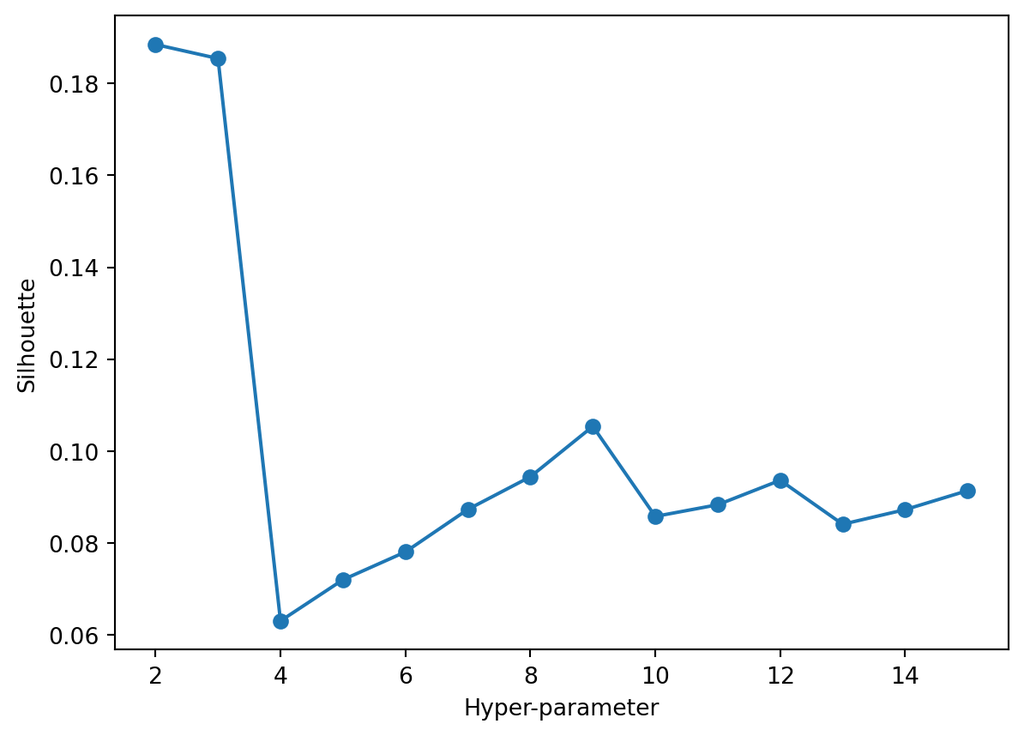

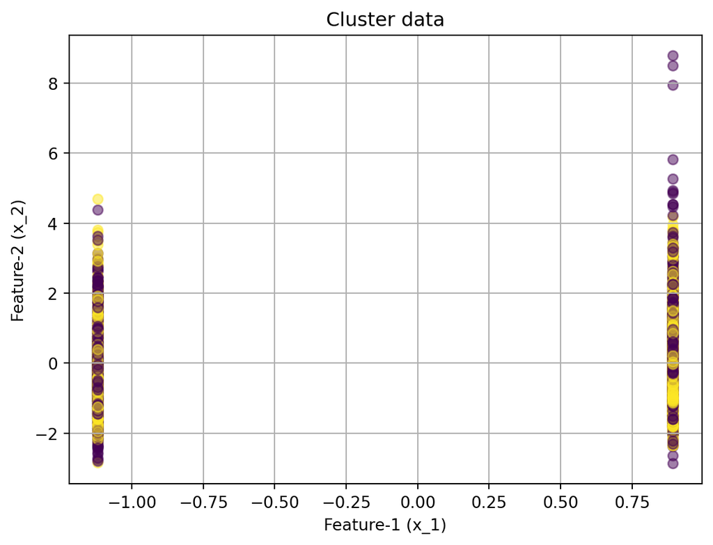

```python
# Hierarchical Clustering
Z = linkage(data_scaled, 'ward')

# Plot dendrogram
plt.figure(figsize=(10, 7))
dendrogram(Z, truncate_mode='lastp', p=12, leaf_rotation=45., leaf_font_size=15., show_contracted=True)
plt.title('Hierarchical Clustering Dendrogram')
plt.xlabel('Cluster size')
plt.ylabel('Distance')
plt.show()


# AGGLOMERATIVE CLUSTERING
opt_labels=maximize_silhouette(data_scaled,algo="ag",nmax=15, i_plot=True)
plot(data_scaled,opt_labels)
```

**Final Results for optimal clusters of Hierarchical clustering**

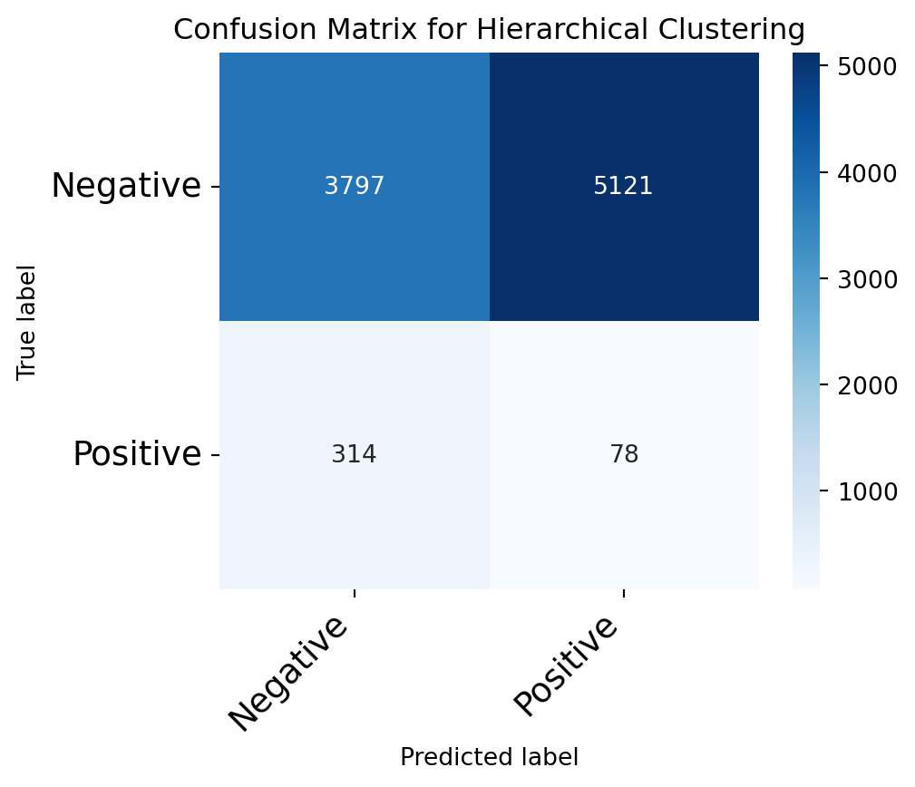

```
Accuracy: 0.4162
Precision: 0.0150
Recall: 0.1990
F1-Score: 0.0279
```

```python
optimal_clusters = 2
agglom_final = AgglomerativeClustering(n_clusters=optimal_clusters, linkage='ward')
hierarchical_clusters = agglom_final.fit_predict(data_scaled)

# Plot confusion matrix for Hierarchical Clustering
cm_hierarchical = confusion_matrix(target, hierarchical_clusters)
fig_hierarchical = plot_confusion_matrix(cm_hierarchical, class_names)
plt.title('Confusion Matrix for Hierarchical Clustering')
plt.show()

precision = precision_score(target, hierarchical_clusters)
recall = recall_score(target, hierarchical_clusters)
f1 = f1_score(target, hierarchical_clusters)
accuracy = accuracy_score(target, hierarchical_clusters)

print(f"Accuracy: {accuracy:.4f}")
print(f"Precision: {precision:.4f}")
print(f"Recall: {recall:.4f}")
print(f"F1-Score: {f1:.4f}")
```

- **Accuracy (41.62%):** This is relatively low, indicating that a significant number of predictions were incorrect.
- **Precision (1.50%):** This is very low, suggesting that when the model predicts the positive class, it is correct only 1.5% of the time.
- **Recall (19.90%):** This is also low, indicating that the model identified less than 20% of all actual positive cases.
- **F1-Score (2.79%):** This very low score indicates a poor balance between precision and recall, suggesting the model is not effective in predicting the positive class accurately.

## References

Dabbura, Imad. 2023. “K-Means Clustering: Algorithm, Applications, Evaluation Methods, and Drawbacks.” *Towards Data Science*. https://towardsdatascience.com/k-means-clustering-algorithm-applications-evaluation-methods-and-drawbacks-aa03e644b48a.

R Project. n.d. “Framingham.” riskCommunicator package documentation. https://search.r-project.org/CRAN/refmans/riskCommunicator/html/framingham.html.